# Project Python Foundations: FoodHub Data Analysis

**Marks: 60 points**

### Context

The number of restaurants in New York is increasing day by day. Lots of students and busy professionals rely on those restaurants due to their hectic lifestyles. Online food delivery service is a great option for them. It provides them with good food from their favorite restaurants. A food aggregator company FoodHub offers access to multiple restaurants through a single smartphone app.

The app allows the restaurants to receive a direct online order from a customer. The app assigns a delivery person from the company to pick up the order after it is confirmed by the restaurant. The delivery person then uses the map to reach the restaurant and waits for the food package. Once the food package is handed over to the delivery person, he/she confirms the pick-up in the app and travels to the customer's location to deliver the food. The delivery person confirms the drop-off in the app after delivering the food package to the customer. The customer can rate the order in the app. The food aggregator earns money by collecting a fixed margin of the delivery order from the restaurants.

### Objective

The food aggregator company has stored the data of the different orders made by the registered customers in their online portal. They want to analyze the data to get a fair idea about the demand of different restaurants which will help them in enhancing their customer experience. Suppose you are a Data Scientist at Foodhub and the Data Science team has shared some of the key questions that need to be answered. Perform the data analysis to find answers to these questions that will help the company to improve the business.

### Data Description

The data contains the different data related to a food order. The detailed data dictionary is given below.

### Data Dictionary

- order_id: Unique ID of the order
- customer_id: ID of the customer who ordered the food
- restaurant_name: Name of the restaurant
- cuisine_type: Cuisine ordered by the customer
- cost_of_the_order: Cost of the order
- day_of_the_week: Indicates whether the order is placed on a weekday or weekend (The weekday is from Monday to Friday and the weekend is Saturday and Sunday)
- rating: Rating given by the customer out of 5
- food_preparation_time: Time (in minutes) taken by the restaurant to prepare the food. This is calculated by taking the difference between the timestamps of the restaurant's order confirmation and the delivery person's pick-up confirmation.
- delivery_time: Time (in minutes) taken by the delivery person to deliver the food package. This is calculated by taking the difference between the timestamps of the delivery person's pick-up confirmation and drop-off information

### **Please read the instructions carefully before starting the project.**

This is a commented Jupyter IPython Notebook file in which all the instructions and tasks to be performed are mentioned. Read along carefully to complete the project.

- Blanks '**___**' are provided in the notebook that needs to be filled with an appropriate code to get the correct result. Please replace the blank with the right code snippet. With every '**___**' blank, there is a comment that briefly describes what needs to be filled in the blank space.
- Identify the task to be performed correctly, and only then proceed to write the required code.
- Fill the code wherever asked by the commented lines like "# write your code here" or "# complete the code". Running incomplete code may throw an error.
- Please run the codes in a sequential manner from the beginning to avoid any unnecessary errors.
- You can the results/observations derived from the analysis here and use them to create your final presentation.

### Let us start by importing the required libraries

```python
# Import libraries for data manipulation
import numpy as np
import pandas as pd

# Import libraries for data visualization
import matplotlib.pyplot as plt
import seaborn as sns
```

### Understanding the structure of the data

```python
# uncomment and run the following lines for Google Colab
from google.colab import drive
drive.mount('/content/drive')
```

```python
# Read the data
df = pd.read_csv('/content/drive/MyDrive/Colab Datafiles/foodhub_order.csv') ## Fill the blank to read the data
# Returns the first 5 rows
df.head()
```

|  | order_id | customer_id | restaurant_name | cuisine_type | cost_of_the_order | day_of_the_week | rating | food_preparation_time | delivery_time |
| --- | --- | --- | --- | --- | --- | --- | --- | --- | --- |
| 0 | 1477147 | 337525 | Hangawi | Korean | 30.75 | Weekend | Not given | 25 | 20 |
| 1 | 1477685 | 358141 | Blue Ribbon Sushi Izakaya | Japanese | 12.08 | Weekend | Not given | 25 | 23 |
| 2 | 1477070 | 66393 | Cafe Habana | Mexican | 12.23 | Weekday | 5 | 23 | 28 |
| 3 | 1477334 | 106968 | Blue Ribbon Fried Chicken | American | 29.20 | Weekend | 3 | 25 | 15 |
| 4 | 1478249 | 76942 | Dirty Bird to Go | American | 11.59 | Weekday | 4 | 25 | 24 |

```python
df.tail()
```

[output not shown]

### **Question 1:** How many rows and columns are present in the data? [0.5 mark]

```python
# Check the shape of the dataset
df.shape ## Fill in the blank
rows, columns = df.shape
print(f"Number of rows: {rows}")
print(f"Number of columns: {columns}")
```

```
Number of rows: 1898
Number of columns: 9
```

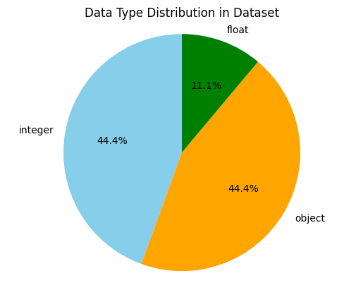

```python
# Let's create a DataFrame to simulate the user's data
data = {
    'Data Types': ['integer', 'object', 'float'],
    'Count': [4, 4, 1]
}

df = pd.DataFrame(data)

# Now let's create a pie chart
fig, ax = plt.subplots()
ax.pie(df['Count'], labels=df['Data Types'], autopct='%1.1f%%', startangle=90, colors=['skyblue', 'orange', 'green'])
ax.axis('equal')  # Equal aspect ratio ensures that pie is drawn as a circle.

plt.title('Data Type Distribution in Dataset')
plt.show()
```

**Shape Observations**

- Number of rows = 1898
- Number of columns = 9

### **Question 2:** What are the datatypes of the different columns in the dataset? [0.5 mark]

```python
df.info()
column_datatypes = df.dtypes
# Display the datatypes
print(column_datatypes)
df.info()
```

```
<class 'pandas.core.frame.DataFrame'>
RangeIndex: 1898 entries, 0 to 1897
Data columns (total 9 columns):
 #   Column                 Non-Null Count  Dtype
---  ------                 --------------  -----
 0   order_id               1898 non-null   int64
 1   customer_id            1898 non-null   int64
 2   restaurant_name        1898 non-null   object
 3   cuisine_type           1898 non-null   object
 4   cost_of_the_order      1898 non-null   float64
 5   day_of_the_week        1898 non-null   object
 6   rating                 1898 non-null   object
 7   food_preparation_time  1898 non-null   int64
 8   delivery_time          1898 non-null   int64
dtypes: float64(1), int64(4), object(4)
memory usage: 133.6+ KB
order_id                   int64
customer_id                int64
restaurant_name           object
cuisine_type              object
cost_of_the_order        float64
day_of_the_week           object
rating                    object
food_preparation_time      int64
delivery_time              int64
dtype: object
<class 'pandas.core.frame.DataFrame'>
RangeIndex: 1898 entries, 0 to 1897
Data columns (total 9 columns):
 #   Column                 Non-Null Count  Dtype
---  ------                 --------------  -----
 0   order_id               1898 non-null   int64
 1   customer_id            1898 non-null   int64
 2   restaurant_name        1898 non-null   object
 3   cuisine_type           1898 non-null   object
 4   cost_of_the_order      1898 non-null   float64
 5   day_of_the_week        1898 non-null   object
 6   rating                 1898 non-null   object
 7   food_preparation_time  1898 non-null   int64
 8   delivery_time          1898 non-null   int64
dtypes: float64(1), int64(4), object(4)
memory usage: 133.6+ KB
```

```python
df.dtypes
```

```
order_id                   int64
customer_id                int64
restaurant_name           object
cuisine_type              object
cost_of_the_order        float64
day_of_the_week           object
rating                    object
food_preparation_time      int64
delivery_time              int64
dtype: object
```

```python
# Check for unique values in the 'cost_of_the_order' column to identify any non-numeric values
unique_values = df['cost_of_the_order'].unique()
print(unique_values)

# Check for any missing (NaN) values in the column
missing_values = df['cost_of_the_order'].isnull().sum()
print("Missing values:", missing_values)

# Attempt to convert the column to float and catch any errors
try:
    df['cost_of_the_order'] = df['cost_of_the_order'].astype(float)
except ValueError as e:
    print("Error:", e)
```

[output not shown]

**Datatypes Observations**

- int = 4
- object = 4
- float = 1 **Actions** Convert ratings into int

### **Question 3:** Are there any missing values in the data? If yes, treat them using an appropriate method. [1 Mark]

```python
# Checking for missing values in the data
df.isnull().sum()
```

```
order_id                 0
customer_id              0
restaurant_name          0
cuisine_type             0
cost_of_the_order        0
day_of_the_week          0
rating                   0
food_preparation_time    0
delivery_time            0
dtype: int64
```

**Missing Values Observations** There are no missing values in the data

```python
df.duplicated().sum()
```

```
0
```

### **Question 4:** Check the statistical summary of the data. What is the minimum, average, and maximum time it takes for food to be prepared once an order is placed? [2 marks]

```python
# Get the summary statistics of the numerical data
df.describe().T
```

|  | count | mean | std | min | 25% | 50% | 75% | max |
| --- | --- | --- | --- | --- | --- | --- | --- | --- |
| order_id | 1898.0 | 1.477496e+06 | 548.049724 | 1476547.00 | 1477021.25 | 1477495.50 | 1.477970e+06 | 1478444.00 |
| customer_id | 1898.0 | 1.711685e+05 | 113698.139743 | 1311.00 | 77787.75 | 128600.00 | 2.705250e+05 | 405334.00 |
| cost_of_the_order | 1898.0 | 1.649885e+01 | 7.483812 | 4.47 | 12.08 | 14.14 | 2.229750e+01 | 35.41 |
| food_preparation_time | 1898.0 | 2.737197e+01 | 4.632481 | 20.00 | 23.00 | 27.00 | 3.100000e+01 | 35.00 |
| delivery_time | 1898.0 | 2.416175e+01 | 4.972637 | 15.00 | 20.00 | 25.00 | 2.800000e+01 | 33.00 |

### **Question 5:** How many orders are not rated? [1 mark]

```python
df['rating'].value_counts() # counts the number of ratings and sum the types
```

```
Not given    736
5            588
4            386
3            188
Name: rating, dtype: int64
```

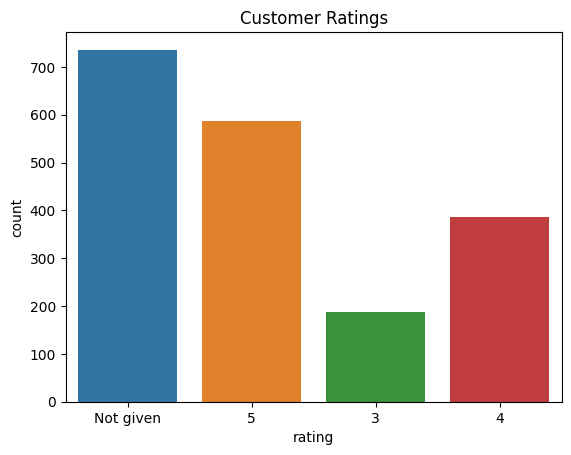

```python
sns.countplot(data = df,x = 'rating',hue ='rating');
plt.title("Customer Ratings")
plt.show()
```

```python
(df['rating'].value_counts(normalize=True) * 100).round(2)
```

```
Not given    38.78
5            30.98
4            20.34
3             9.91
Name: rating, dtype: float64
```

**Observations**

1. Number of ratings not given = 736
2. Number of 5 str ratings = 588
3. Number of 4 str ratings = 386
4. Number of 3 str ratings = 188 **Actions** Probably should convert 'Not Given' to NAN but I have decided to keep it on for the moment to study if there is any pattern to why the feedback hasn't been given.

### Exploratory Data Analysis (EDA)

### **Question 6:** Explore all the variables and provide observations on their distributions. (Generally, histograms, boxplots, countplots, etc. are used for univariate exploration.) [9 marks]

#### Order ID

```python
# check unique order ID
df['order_id'].nunique()
```

```
1898
```

#### Customer ID

```python
# check unique customer ID
df['customer_id'].nunique()  ## Complete the code to find out number of unique Customer ID
```

```
1200
```

#### Restaurant name

```python
# check unique Restaurant Name
df['restaurant_name'].unique()  ## Complete the code to find out number of unique Restaurant Name
```

```
array(['Hangawi', 'Blue Ribbon Sushi Izakaya', 'Cafe Habana',
       'Blue Ribbon Fried Chicken', 'Dirty Bird to Go',
       'Tamarind TriBeCa', 'The Meatball Shop', 'Barbounia',
       'Anjappar Chettinad', 'Bukhara Grill',
       'Big Wong Restaurant \x8c_¤¾Ñ¼', 'Empanada Mama (closed)', 'Pylos',
       "Lucky's Famous Burgers", 'Shake Shack', 'Sushi of Gari',
       'RedFarm Hudson', 'Blue Ribbon Sushi',
       'Five Guys Burgers and Fries', 'Tortaria', 'Cafe Mogador',
       'Otto Enoteca Pizzeria', 'Vezzo Thin Crust Pizza',
       'Sushi of Gari 46', 'The Kati Roll Company', 'Klong',
       '5 Napkin Burger', 'TAO', 'Parm', 'Sushi Samba',
       'Haru Gramercy Park', 'Chipotle Mexican Grill $1.99 Delivery',
       'RedFarm Broadway', 'Cafeteria', 'DuMont Burger',
       "Sarabeth's East", 'Hill Country Fried Chicken', 'Bistango',
       "Jack's Wife Freda", "Mamoun's Falafel", 'Prosperity Dumpling',
       'Blue Ribbon Sushi Bar & Grill', 'Westville Hudson',
       'Blue Ribbon Brooklyn', 'Nobu Next Door', 'Osteria Morini',
       'Haandi', 'Benihana', 'Han Dynasty', 'Chote Nawab',
       'Mission Cantina', "Xi'an Famous Foods", 'Rubirosa',
       "Joe's Shanghai \x8e_À\x8eü£¾÷´", 'Bareburger', 'The Odeon',
       'Pongsri Thai', 'Yama Japanese Restaurant', 'Momoya',
       'Balthazar Boulangerie', 'CafÌ© China', 'Boqueria',
       'Song Thai Restaurant & Bar', 'Five Leaves',
       'Pinto Nouveau Thai Bistro', "Amy Ruth's", 'Pepe Giallo',
       'indikitch', 'Yama 49', 'Piccolo Angolo', 'Pepe Rosso To Go',
       "L'Express", 'Amma', 'Delicatessen', "S'MAC",
       "Vanessa's Dumplings", 'Bhatti Indian Grill', 'Taro Sushi',
       'Donburi-ya', 'Hatsuhana', 'Samurai Mama', 'Waverly Diner',
       'Tarallucci e Vino Restaurant', "P.J. Clarke's",
       'Lantern Thai Kitchen', 'ilili Restaurant', 'The Smile',
       "Vanessa's Dumpling House", "Bubby's ", 'Woorijip',
       'Dirty Bird To Go (archived)', 'Haveli Indian Restaurant',
       'Dos Caminos', 'da Umberto', 'Sushi of Gari Tribeca',
       'Burger Joint', 'Room Service', "Sarabeth's Restaurant",
       'Xe May Sandwich Shop', 'Hibino', 'Mira Sushi', 'Melt Shop',
       'J. G. Melon', 'Hummus Place', 'Saravanaa Bhavan',
       'Friend of a Farmer', 'The Loop', 'Balade', 'Posto',
       'Terakawa Ramen', 'Kambi Ramen House', 'Wo Hop Restaurant',
       'Spice Thai', "Dickson's Farmstand Meats",
       'UVA Wine Bar & Restaurant', 'Serafina Fabulous Pizza',
       'Gaia Italian Cafe', 'Chola Eclectic Indian Cuisine',
       'Hot Kitchen', 'Junoon', 'Ravagh Persian Grill', 'Rohm Thai',
       'Dig Inn Seasonal Market', 'Olea', 'Cho Dang Gol',
       'El Parador Cafe', 'Socarrat Paella Bar',
       "Don's Bogam BBQ & Wine Bar", 'Alidoro', "Tony's Di Napoli",
       'Cipriani Le Specialita', 'Sushi Choshi', 'Kanoyama', 'V-Nam Cafe',
       'Zero Otto Nove', 'Dos Caminos Soho', 'Go! Go! Curry!',
       'La Follia', 'Izakaya Ten', '12 Chairs', 'Philippe Chow',
       'The MasalaWala', 'brgr', "Carmine's", 'Asuka Sushi', 'Aurora',
       "Sarabeth's", 'Crema Restaurante', "Big Daddy's",
       'Moonstruck on Second', 'Cafe de La Esquina', 'Olive Garden',
       '67 Burger', 'Tres Carnes', "Schnipper's Quality Kitchen",
       'Nha Trang One', 'Market Table', 'Galli Restaurant',
       'Hampton Chutney Co.', 'Byblos Restaurant',
       'Grand Sichuan International', 'Le Grainne Cafe', 'Il Bambino',
       'Kori Restaurant and Bar', 'DespaÌ±a', 'Lamarca Pasta',
       'Lucky Strike', "Paul & Jimmy's", 'Hunan Manor', "Coppola's East",
       'Emporio', 'Wa Jeal', 'Le Zie 2000 Trattoria', 'Rye House',
       "Hiroko's Place", 'Frank Restaurant', "Sarabeth's West",
       "'wichcraft"], dtype=object)
```

```python
# check for number of resturants
df['restaurant_name'].nunique()
```

```
178
```

```python
# Identify repeat customers by counting the occurrences of each customer ID
repeat_customers = df['customer_id'].value_counts()

# Filter for customer IDs that occur more than once, which indicates repeat customers
repeat_customers = repeat_customers[repeat_customers > 1]

# The 'repeat_customers' series now contains the customer IDs and the count of their repeat orders
print(repeat_customers)
repeat_customers.unique()
```

```
52832     13
47440     10
83287      9
250494     8
259341     7
          ..
79255      2
342107     2
371590     2
106968     2
155124     2
Name: customer_id, Length: 416, dtype: int64
```

```
array([13, 10,  9,  8,  7,  6,  5,  4,  3,  2])
```

```python
# Filter the DataFrame for rows where the customer_id is 52832
orders_from_customer_52832 = df[df['customer_id'] == 52832]

# Display these rows
print(orders_from_customer_52832)
```

```
      order_id  customer_id             restaurant_name    cuisine_type  \
247    1478179        52832                 Han Dynasty         Chinese
272    1477314        52832            ilili Restaurant  Middle Eastern
517    1476916        52832   Dickson's Farmstand Meats        American
526    1478160        52832                  Donburi-ya        Japanese
632    1478265        52832                 Dos Caminos         Mexican
670    1477302        52832  Don's Bogam BBQ & Wine Bar          Korean
855    1477041        52832                      Junoon          Indian
1039   1477013        52832                  Donburi-ya        Japanese
1070   1476828        52832                  Donburi-ya        Japanese
1105   1478245        52832                      Junoon          Indian
1110   1477129        52832                 Han Dynasty         Chinese
1483   1477179        52832                   L'Express          French
1768   1477075        52832            ilili Restaurant  Middle Eastern

```

[output cut: 29 more lines]

#### Cuisine type

```python
# Check unique cuisine type
df['cuisine_type'].nunique() ## Complete the code to find out  number of  unique cuisine type
```

```
14
```

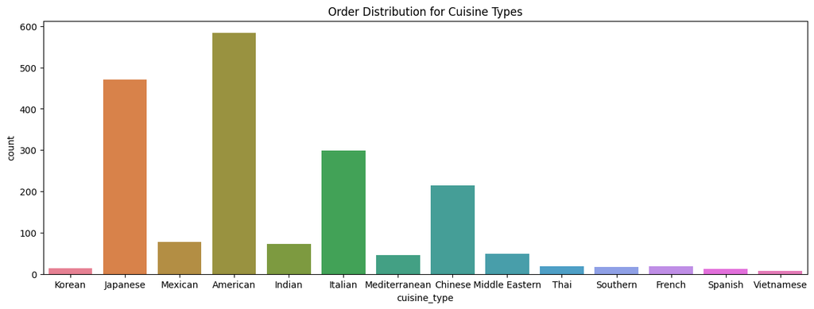

```python
plt.figure(figsize = (15,5))
sns.countplot(data = df, x = 'cuisine_type', hue ='cuisine_type' ); ## Create a countplot for cuisine type.
plt.title("Order Distribution for Cuisine Types")
plt.show()
```

```python
# Identify repeat customers
repeat_customers = df['customer_id'].value_counts()
repeat_customer_ids = repeat_customers[repeat_customers > 1].index# Filter orders made by repeat customers
repeat_customers_orders = df[df['customer_id'].isin(repeat_customer_ids)]

# Group by customer_id and cuisine_type, then count the number of occurrences
cuisine_orders_by_repeat_customers = repeat_customers_orders.groupby(['customer_id', 'cuisine_type']).size().reset_index(name='count')

# Sort the results by customer_id and count to see the most popular cuisines for each repeat customer
cuisine_orders_by_repeat_customers.sort_values(by=['customer_id', 'count'], ascending=[True, False], inplace=True)

# If you want to see the most popular cuisine for each customer
most_popular_cuisine_per_customer = cuisine_orders_by_repeat_customers.groupby('customer_id').first().reset_index()

print(most_popular_cuisine_per_customer[['customer_id', 'cuisine_type']])
```

```
     customer_id cuisine_type
0           6987     Southern
1          14869     American
2          27609     Japanese
3          35309     Japanese
4          35432     Japanese
..           ...          ...
411       395616      Italian
412       396432     Japanese
413       398952      Chinese
414       399520   Vietnamese
415       399729     American

[416 rows x 2 columns]
```

#### Cost of the order

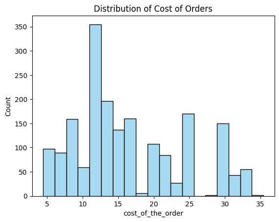

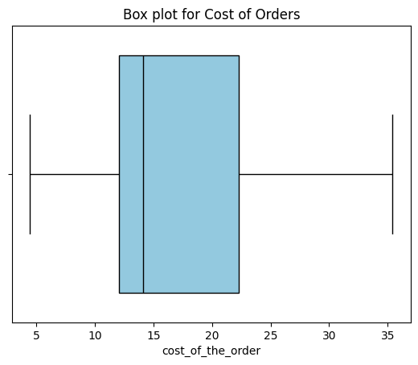

```python
sns.histplot(data=df,x='cost_of_the_order',color = 'skyblue') ## Histogram for the cost of order
plt.title("Distribution of Cost of Orders")
plt.show()
sns.boxplot(data=df,x='cost_of_the_order',color = 'skyblue',boxprops=dict(edgecolor="black"),
            whiskerprops=dict(color="black"),
            capprops=dict(color="black"),
            medianprops=dict(color="black")) ## Boxplot for the cost of order
plt.title("Box plot for Cost of Orders")
plt.show()
```

#### Food Order Distribution

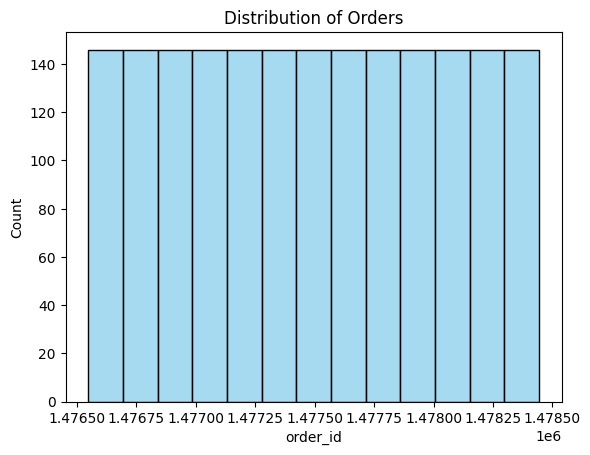

```python
sns.histplot(data=df,x='order_id',color = 'skyblue') ## Histogram for the cost of order
plt.title("Distribution of Orders")
plt.show()
```

#### Day of the week

```python
# # Check the unique values
df['day_of_the_week'].unique() ## Complete the code to check unique values for the 'day_of_the_week' column
```

```
array(['Weekend', 'Weekday'], dtype=object)
```

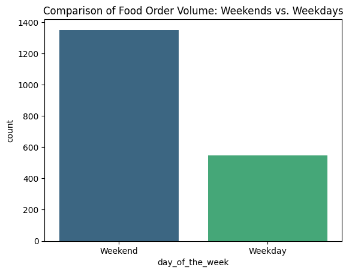

```python
sns.countplot(data = df, x = 'day_of_the_week',hue =  'day_of_the_week',palette="viridis"); ## Complete the code to plot a bar graph for 'day_of_the_week' column
plt.title("Comparison of Food Order Volume: Weekends vs. Weekdays")
plt.show()
```

#### Rating

```python
# Check the unique values
df['rating'].unique() ## Complete the code to check unique values for the 'rating' column
```

```
array(['Not given', '5', '3', '4'], dtype=object)
```

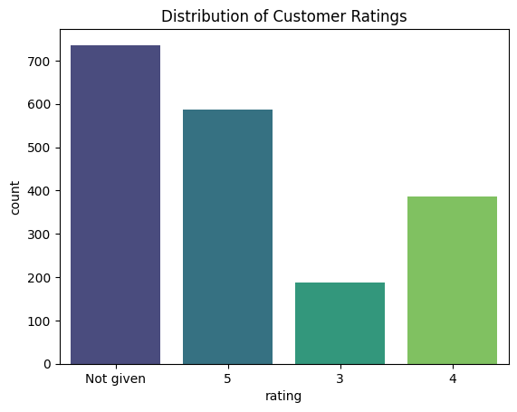

```python
sns.countplot(data = df, x = 'rating', hue = 'rating',palette="viridis"); ## Complete the code to plot bar graph for 'rating' column
plt.title("Distribution of Customer Ratings")
plt.show()
```

#### Food Preparation time

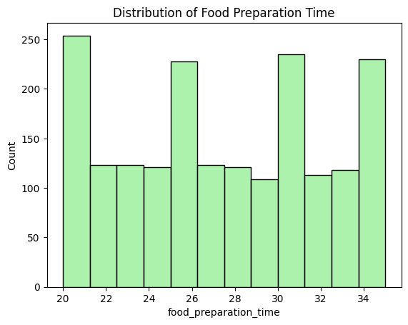

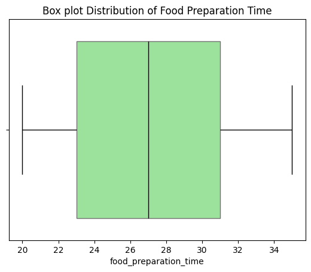

```python
sns.histplot(data=df,x='food_preparation_time',color = 'lightgreen') ## Complete the code to plot the histogram for the food_preparation_time
plt.title('Distribution of Food Preparation Time')
plt.show()
sns.boxplot(data=df,x='food_preparation_time',color = 'lightgreen',whiskerprops=dict(color="black"),
            capprops=dict(color="black"),
            medianprops=dict(color="black")) ## Complete the code to plot the boxplot for the food_preparation_time
plt.title('Box plot Distribution of Food Preparation Time')
plt.show()
```

#### Delivery time

[figure not shown]

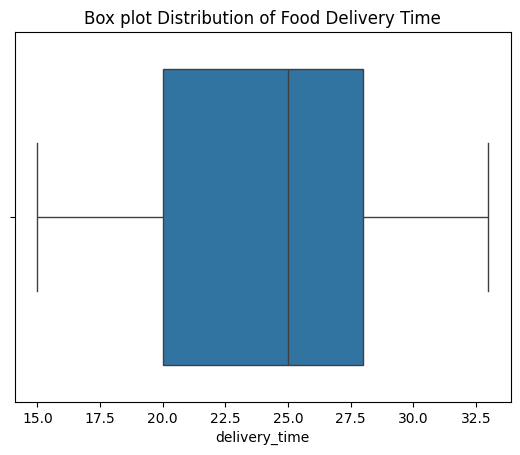

```python
sns.histplot(data=df,x='delivery_time') ## Complete the code to plot the histogram for the delivery time
plt.title('Box plot Distribution of Food Delivery Time')
plt.show()
sns.boxplot(data=df,x='delivery_time') ## Complete the code to plot the boxplot for the delivery time
plt.title('Box plot Distribution of Food Delivery Time')
plt.show()
```

```python
df['total_time'] = df['delivery_time'] + df['food_preparation_time'] # create a new column called total time
df.head()
```

|  | order_id | customer_id | restaurant_name | cuisine_type | cost_of_the_order | day_of_the_week | rating | food_preparation_time | delivery_time | total_time |
| --- | --- | --- | --- | --- | --- | --- | --- | --- | --- | --- |
| 0 | 1477147 | 337525 | Hangawi | Korean | 30.75 | Weekend | Not given | 25 | 20 | 45 |
| 1 | 1477685 | 358141 | Blue Ribbon Sushi Izakaya | Japanese | 12.08 | Weekend | Not given | 25 | 23 | 48 |
| 2 | 1477070 | 66393 | Cafe Habana | Mexican | 12.23 | Weekday | 5 | 23 | 28 | 51 |
| 3 | 1477334 | 106968 | Blue Ribbon Fried Chicken | American | 29.20 | Weekend | 3 | 25 | 15 | 40 |
| 4 | 1478249 | 76942 | Dirty Bird to Go | American | 11.59 | Weekday | 4 | 25 | 24 | 49 |

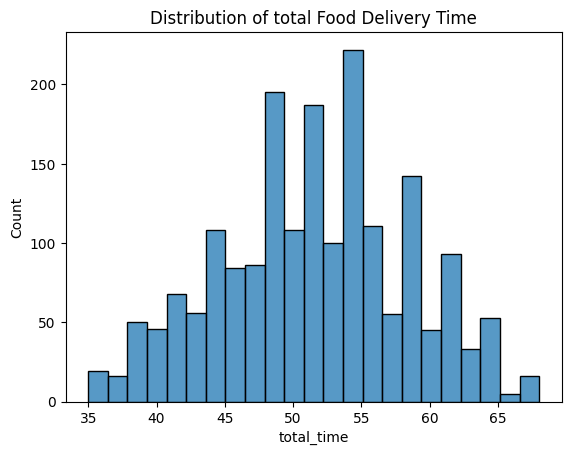

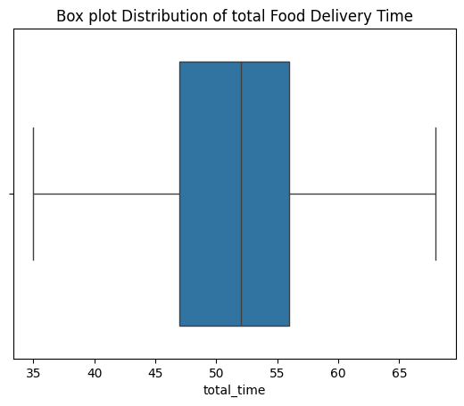

```python
sns.histplot(data=df,x='total_time') ## Complete the code to plot the histogram for the delivery time
plt.title('Distribution of total Food Delivery Time')
plt.show()
sns.boxplot(data=df,x='total_time') ## Complete the code to plot the boxplot for the delivery time
plt.title('Box plot Distribution of total Food Delivery Time')
plt.show()
```

```python
df.describe().T
```

|  | count | mean | std | min | 25% | 50% | 75% | max |
| --- | --- | --- | --- | --- | --- | --- | --- | --- |
| order_id | 1898.0 | 1.477496e+06 | 548.049724 | 1476547.00 | 1477021.25 | 1477495.50 | 1.477970e+06 | 1478444.00 |
| customer_id | 1898.0 | 1.711685e+05 | 113698.139743 | 1311.00 | 77787.75 | 128600.00 | 2.705250e+05 | 405334.00 |
| cost_of_the_order | 1898.0 | 1.649885e+01 | 7.483812 | 4.47 | 12.08 | 14.14 | 2.229750e+01 | 35.41 |
| food_preparation_time | 1898.0 | 2.737197e+01 | 4.632481 | 20.00 | 23.00 | 27.00 | 3.100000e+01 | 35.00 |
| delivery_time | 1898.0 | 2.416175e+01 | 4.972637 | 15.00 | 20.00 | 25.00 | 2.800000e+01 | 33.00 |
| total_time | 1898.0 | 5.153372e+01 | 6.833603 | 35.00 | 47.00 | 52.00 | 5.600000e+01 | 68.00 |

**Observations From Univarient Analysis**

1. The number of order_id (1898) does not match the number of Customer (1200) which indicates a few Customers are repeated.
2. There are 178 Restaurants Listed and 14 Cuisines available to order from
3. America,Japanese,Italian and Chinese cuisines are the most popular ones and Vietnamese is the least popular
4. From the cost distribution (skewed to the right) we can tell most of the orders tend to be on the lower range between $10.00 - $15.00
5. Weekends are a lot busier than the weekdays
6. A good perecentage of ratings (38%) of the orders aren't rated but of the remaining mostly they are 5 and 4 star which is not too bad need to analyse the 9% of 3 star rating for resons behind it.
7. The preparation time has no apparent skewness and also seems to be within a standard range. there are however a few peaks and troughs probably to do with the size of the order. needs to be further analyzed.
8. The delivery time plots indicate that while there is some variability in delivery times the process is fairly consistent without any significant anomalies or outliers.
9. The repeat customers can be rewarded with discounts by creating a loyalty program

### **Question 7:** Which are the top 5 restaurants in terms of the number of orders received? [1 mark]

```python
# Get top 5 restaurants with highest number of orders
df['restaurant_name'].value_counts().head(5) ## Complete the code
```

```
Shake Shack                  219
The Meatball Shop            132
Blue Ribbon Sushi            119
Blue Ribbon Fried Chicken     96
Parm                          68
Name: restaurant_name, dtype: int64
```

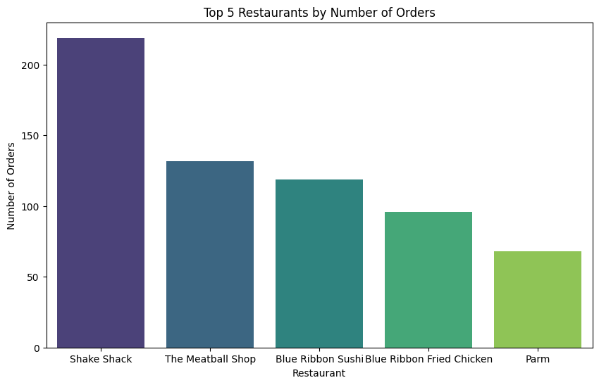

```python
# Data for the top 5 restaurants with the highest number of orders
restaurants = ['Shake Shack', 'The Meatball Shop', 'Blue Ribbon Sushi', 'Blue Ribbon Fried Chicken', 'Parm']
orders = [219, 132, 119, 96, 68]

# Create a Seaborn count plot
plt.figure(figsize=(10,6))
sns.barplot(x=restaurants, y=orders, palette='viridis')

# Adding titles and labels
plt.title('Top 5 Restaurants by Number of Orders')
plt.xlabel('Restaurant')
plt.ylabel('Number of Orders')

# Show the plot
plt.show()
```

**Observations**

The top 5 restaurants with the highest number of orders are

Shake Shack 219

The Meatball Shop 132

Blue Ribbon Sushi 119

Blue Ribbon Fried Chicken 96

Parm 68

### **Question 8:** Which is the most popular cuisine on weekends? [1 mark]

```python
# Get most popular cuisine on weekends
df_weekend = df[df['day_of_the_week'] == 'Weekend']
df_weekend['cuisine_type'].value_counts().idxmax() ## Complete the code to check unique values for the cuisine type on weekend
```

```
'American'
```

**Observations**

The most popular cuisine over the weekend is American

### **Question 9:** What percentage of the orders cost more than 20 dollars? [2 marks]

```python
# Get orders that cost above 20 dollars
df_greater_than_20 = df[df['cost_of_the_order']>20] ## Write the appropriate column name to get the orders having cost above $20

# Calculate the number of total orders where the cost is above 20 dollars
print('The number of total orders that cost above 20 dollars is:', df_greater_than_20.shape[0])

# Calculate percentage of such orders in the dataset
percentage = round((df_greater_than_20.shape[0] / df.shape[0]) * 100, 2)

print("The percentage of orders that cost more than 20 dollars = ",percentage)
```

```
The number of total orders that cost above 20 dollars is: 555
The percentage of orders that cost more than 20 dollars =  29.24
```

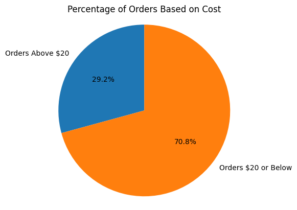

```python
orders_above_20 = df[df['cost_of_the_order'] > 20].shape[0]
total_orders = df.shape[0]
orders_below_or_equal_20 = total_orders - orders_above_20

# Data for pie chart
labels = 'Orders Above $20', 'Orders $20 or Below'
sizes = [orders_above_20, orders_below_or_equal_20]

# Create pie chart
fig, ax = plt.subplots()
ax.pie(sizes, labels=labels, autopct='%1.1f%%', startangle=90)
ax.axis('equal')  # Equal aspect ratio ensures the pie chart is circular.
plt.title('Percentage of Orders Based on Cost')
plt.show()
```

**Observations**

The number of total orders that cost above 20 dollars is: 555

The percentage of orders that cost more than 20 dollars = 29.24

### **Question 10:** What is the mean order delivery time? [1 mark]

```python
# Get the mean delivery time
mean_del_time = df['delivery_time'].mean()  ## Write the appropriate function to obtain the mean delivery time

print('The mean delivery time for this dataset is', round(mean_del_time, 2), 'minutes')
```

```
The mean delivery time for this dataset is 24.16 minutes
```

**Observations**

The mean delivery time for this dataset is 24.16 minutes

### **Question 11:** The company has decided to give 20% discount vouchers to the top 3 most frequent customers. Find the IDs of these customers and the number of orders they placed. [1 mark]

```python
# Get the counts of  each customer_id
df['customer_id'].value_counts().head(5)  ## Write the appropriate column name to get the top 5 cmost frequent customers
```

```
52832     13
47440     10
83287      9
250494     8
259341     7
Name: customer_id, dtype: int64
```

**Observations**

The top 3 most frequent customers based on their Customer_Ids are

52832

47440

83287

### **Question 12:** Perform a multivariate analysis to explore relationships between the important variables in the dataset. (It is a good idea to explore relations between numerical variables as well as relations between numerical and categorical variables) [10 marks]

#### Cuisine vs Cost of the order

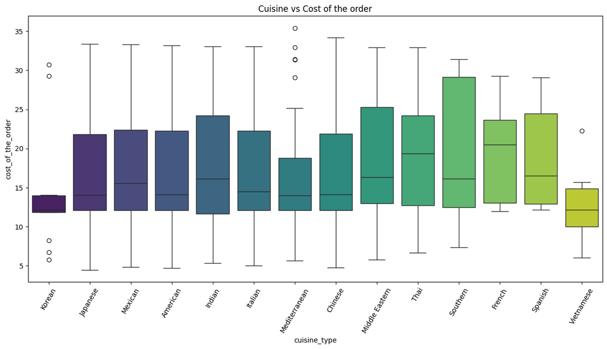

```python
# Relationship between cost of the order and cuisine type
plt.figure(figsize=(15,7))
sns.boxplot(x = "cuisine_type", y = "cost_of_the_order",hue = "cuisine_type",legend = False, data = df, palette = 'viridis')
plt.title('Cuisine vs Cost of the order')
plt.xticks(rotation = 60)
plt.show()
```

```python
# Group the data by cuisine type and sum the cost of the orders
gross_earnings_by_cuisine = df.groupby('cuisine_type')['cost_of_the_order'].sum()

# Find the cuisine with the highest total earnings
highest_grossing_cuisine = gross_earnings_by_cuisine.idxmax()
highest_grossing_earnings = gross_earnings_by_cuisine.max()
print('Highest grossing Cuisine = ',highest_grossing_cuisine)
print('Highest grossing earnings = ',highest_grossing_earnings)

# Filter the DataFrame for American cuisine orders on weekends
american_weekend_orders = df[(df['cuisine_type'] == 'American') & (df['day_of_the_week'] == 'Weekend')]

# Calculate the average cost of these orders
average_cost_american_weekend = american_weekend_orders['cost_of_the_order'].mean()

print(f"The average cost of American cuisine orders on weekends is ${average_cost_american_weekend:.2f}")

#Calculate th etotal cost of American orders
total_cost_american_weekend = american_weekend_orders['cost_of_the_order'].sum()
print(f"The total cost of American cuisine orders on weekends is ${total_cost_american_weekend:.2f}")
```

```
Highest grossing Cuisine =  American
Highest grossing earnings =  9530.78
The average cost of American cuisine orders on weekends is $16.73
The total cost of American cuisine orders on weekends is $6943.67
```

**Observations for Cuisine vs Cost of the order**

1. Southeren has the highest variation and Korean the least in its prices based on IQR
2. French and Thai are relatively have high priced items on the menu while American and Japanese are lower based on their median and therefore might effect its popularity
3. Mediterranean seems to have very highly piced orders making them outliers worth considering for later analysis
4. There are two out of the norm outliers on the higher end for Korean cuisine and it needs further analysis

#### Cuisine vs Food Preparation time

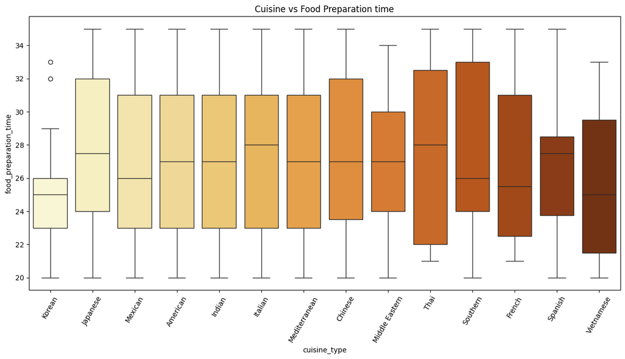

```python
# Relationship between food preparation time and cuisine type
plt.figure(figsize=(15,7))
sns.boxplot(x = 'cuisine_type', y = 'food_preparation_time', data = df, palette = 'YlOrBr',hue = 'cuisine_type',legend = False)  ## Complete the code to visualize the relationship between food preparation time and cuisine type using boxplot
plt.xticks(rotation = 60)
plt.title('Cuisine vs Food Preparation time')
plt.show()
```

```python
df.groupby('cuisine_type')['restaurant_name'].nunique()
```

```
cuisine_type
American          41
Chinese           16
French             3
Indian            14
Italian           31
Japanese          29
Korean             5
Mediterranean      5
Mexican           11
Middle Eastern     7
Southern           2
Spanish            3
Thai               9
Vietnamese         3
Name: restaurant_name, dtype: int64
```

**Observation for Cuisine vs Food Preparation time**

1. The spread of food preparation times varies across different cuisines. Korean, vietnamese and Southern appear to have shorter food prep time while Spanish, Tahi and italian seem on the higher end
2. As observed above Korean cuisine seems to have a few outliers on the higher this needs further analysis 3.Many of the cuisines have simialr range of preparation time based on the comparison of their IQR

#### Day of the Week vs Delivery time

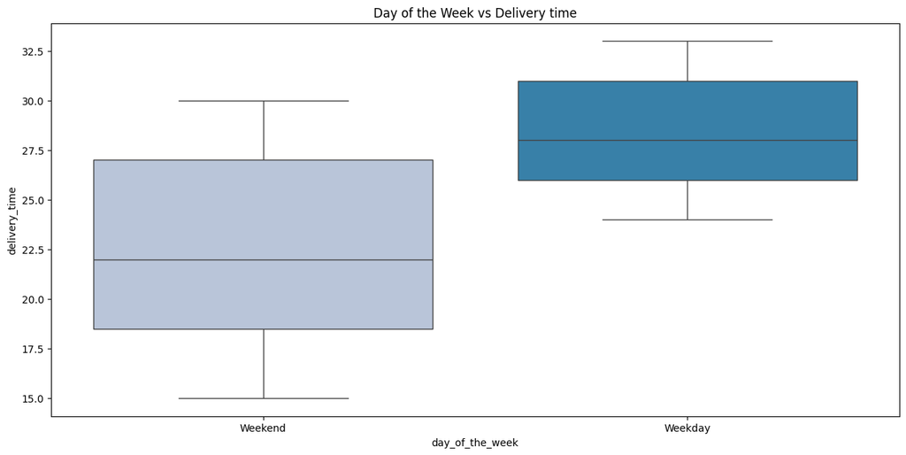

```python
# Relationship between day of the week and delivery time
plt.figure(figsize=(15,7))
sns.boxplot(x = 'day_of_the_week', y = 'delivery_time', data = df, palette = 'PuBu',hue = 'day_of_the_week',legend = False)  ## Complete the code to visualize the relationship between day of the week and delivery time using boxplot
plt.title('Day of the Week vs Delivery time')
plt.show()
```

**Observation for Day of the Week vs Delivery time**

1. The range of weekend delivery time is more than weekdays showing more variation
2. The weekday range is tighter compared to the weekends suggesting delivery times are slightly longer

#### Run the below code and write your observations on the revenue generated by the restaurants.

```python
df.groupby(['restaurant_name'])['cost_of_the_order'].sum().sort_values(ascending = False).head(14)
```

```
restaurant_name
Shake Shack                      3579.53
The Meatball Shop                2145.21
Blue Ribbon Sushi                1903.95
Blue Ribbon Fried Chicken        1662.29
Parm                             1112.76
RedFarm Broadway                  965.13
RedFarm Hudson                    921.21
TAO                               834.50
Han Dynasty                       755.29
Blue Ribbon Sushi Bar & Grill     666.62
Rubirosa                          660.45
Sushi of Gari 46                  640.87
Nobu Next Door                    623.67
Five Guys Burgers and Fries       506.47
Name: cost_of_the_order, dtype: float64
```

**Observations on Revenue Generated by Restaurants**

1. Shake Shack tops the list with a significant margin, indicating that it is a popular choice among FoodHub users, generating the highest revenue
2. The presence of restaurants like Blue Ribbon Sushi, TAO, and Nobu Next Door suggests that higher-end restaurants are also generating substantial revenue through the FoodHub platform.
3. Multiple sushi restaurants are listed (Blue Ribbon Sushi, Sushi of Gari, Nobu Next Door), which could indicate a high demand for sushi among FoodHub users. 4.The list includes both chain restaurants (e.g., Shake Shack, Five Guys) and individual or localized establishments (e.g., Parm, Rubirosa), showing that both types of operations can be successful on the platform.

#### Rating vs Delivery time

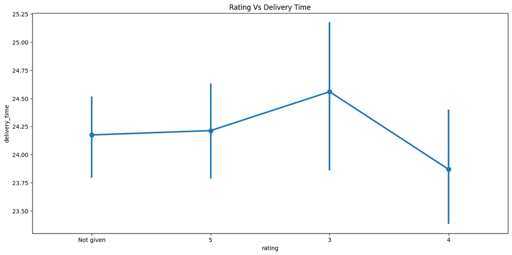

```python
# Relationship between rating and delivery time
plt.figure(figsize=(15, 7))
sns.pointplot(x = 'rating', y = 'delivery_time', data = df)
plt.title("Rating Vs Delivery Time")
plt.show()
```

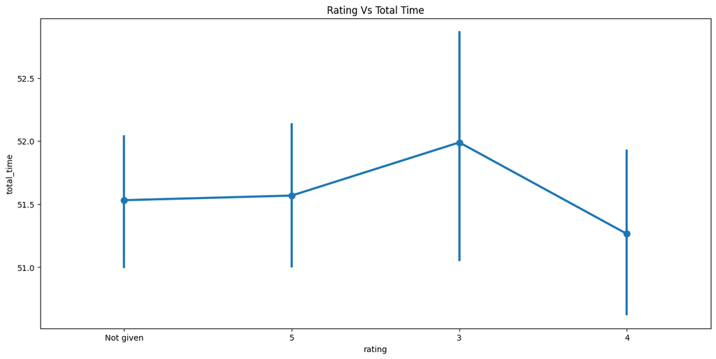

```python
# Relationship between rating and delivery time
plt.figure(figsize=(15, 7))
sns.pointplot(x = 'rating', y = 'total_time', data = df)
plt.title("Rating Vs Total Time")
plt.show()
```

#### Rating vs Food preparation time

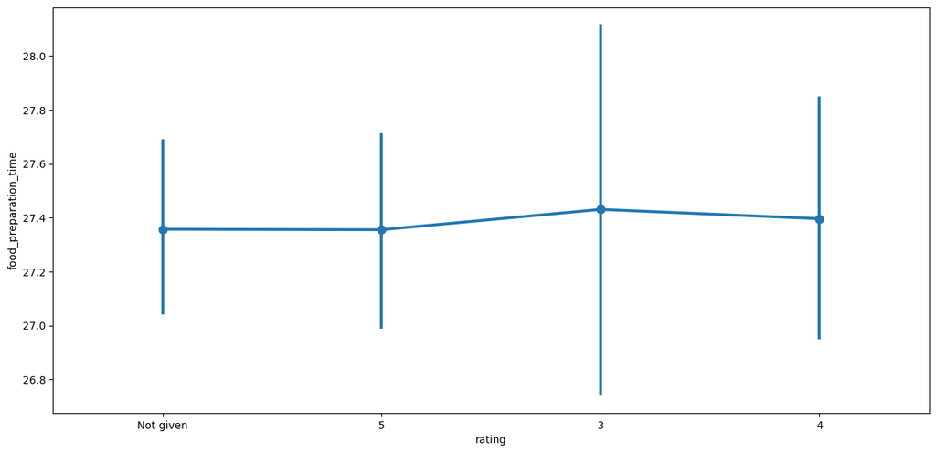

```python
# Relationship between rating and food preparation time
plt.figure(figsize=(15, 7))
sns.pointplot(x = 'rating', y = 'food_preparation_time', data = df)  ## Complete the code to visualize the relationship between rating and food preparation time using pointplot
plt.show()
```

**Observations on the Relationship Between Rating and Food Preparation Time**

1. No Clear Trend: Unlike what might be expected, there is no clear trend indicating that quicker preparation times lead to higher ratings. The data suggests that other factors, possibly including the quality of the food, service, or accuracy of the order, also play significant roles in customer satisfaction.

#### Rating vs Cost of the order

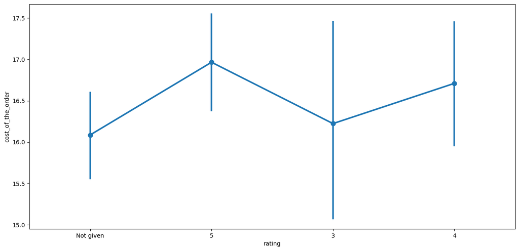

```python
# Relationship between rating and cost of the order
plt.figure(figsize=(15, 7))
sns.pointplot(x = 'rating', y = 'cost_of_the_order', data = df)   ## Complete the code to visualize the relationship between rating and cost of the order using pointplot
plt.show()
```

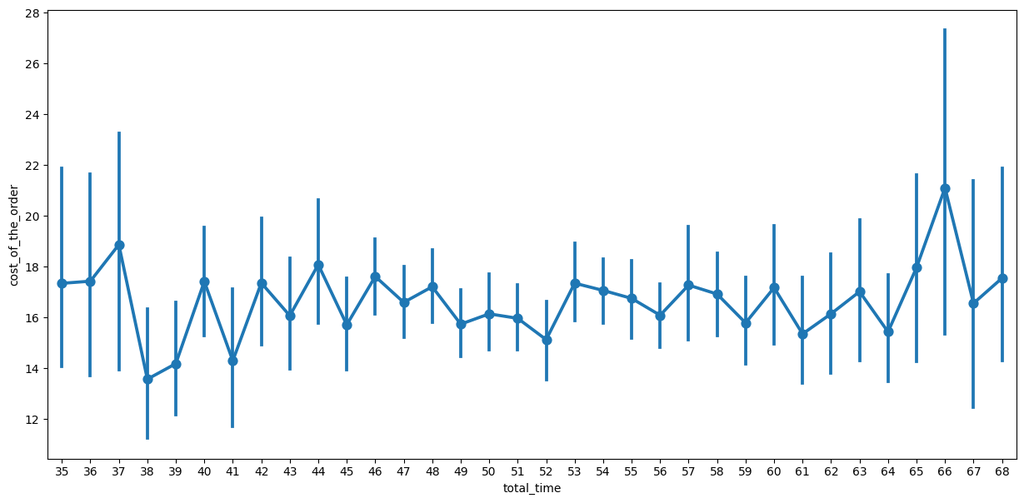

```python
# Relationship between rating and cost of the order
plt.figure(figsize=(15, 7))
sns.pointplot(x = 'total_time', y = 'cost_of_the_order', data = df)   ## Complete the code to visualize the relationship between rating and cost of the order using pointplot
plt.show()
```

**Observations on the Relationship Between Rating and Cost of Order**

1. The data does not show a direct correlation between the cost of the order and the rating given. While there might be a slight trend where higher ratings correspond with higher average costs, the considerable overlap in the ranges of costs for each rating suggests that the cost is not the sole determinant of customer satisfaction as reflected in the ratings 2.The average cost of orders seems to fluctuate with different ratings. It does not show a clear pattern where higher ratings correspond to higher or lower costs consistently.